# HW7, Owen, 5714

## Homework #7

# Instructions

Use R Markdown for this and all future Homework. You can submit your R Markdown compiled document in a Word, pdf (if you have LaTeX installed on your computer), or html file to the course canvas page. Your work will be graded as 1 (complete) if at least 70% of the questions are answered correctly (and/or an obvious “good faith” effort), or 0 (incomplete) otherwise. For this and all homework assignments, make sure to include in your R Markdown document the R commands you used.

All questions for this homework relate to a salary dataset used in in-class exercise 2 and homework 4, as well as is in previous lectures. Data were collected from 1976 - 1995 on non-medical faculty, and include monthly salary, sex, highest degree attained, year of highest degree, field, year hired, rank, and administrative duties. The dataset is available in the “files” folder within the Canvas course webpage. It is also available on the web at:

http://faculty.washington.edu/tathornt/Biost509/DataSets/salary.txt.

# Q1. Create a subset of the salary dataset with missing salary observations removed.

[Hint: use the subset() function]

```r
salary <- read.table("~/Desktop/BIOST_509_2017/salary.txt",header=TRUE)
salary_narm <- subset(salary,!is.na(salary))
```

# Q2. Use a for loop to obtain the following statistics for each UW faculty member: (1) the number of salary observations, (2) median salary, (3) minimum salary, (5) maximum salary

```r
indiv <- unique(salary_narm$id)
statsbyid=matrix(0,length(indiv),5)
n_id=0
for(id in indiv){
  n_id=n_id+1
  tmp=salary_narm$salary[salary_narm$id==id]
  statsbyid[n_id,1] <- length(tmp)
  statsbyid[n_id,2] <- mean(tmp,na.rm =TRUE)
  statsbyid[n_id,3] <- median(tmp,na.rm =TRUE)
  statsbyid[n_id,4] <- min(tmp,na.rm =TRUE)
  statsbyid[n_id,5] <- max(tmp,na.rm =TRUE)
}
statsbyid <- data.frame(statsbyid)
rownames(statsbyid) <- indiv
colnames(statsbyid) <- c("number","mean","median","min","max")
head(statsbyid,10)
```

```
##    number      mean    median       min       max
## 1       1  6684.000  6684.000  6684.000  6684.000
## 2       2  4812.000  4812.000  4743.000  4881.000
## 6       5 11710.600 11840.000 11182.000 12184.000
## 7      20  3134.600  3018.000  1730.000  4604.000
## 8       1  4047.674  4047.674  4047.674  4047.674
## 9       9  4855.667  5022.000  4105.000  5472.000
## 10     15  5397.933  5015.000  3250.000  7494.000
## 12     20  5616.514  5127.500  2339.000  9286.000
## 13     20  5078.000  4191.500  1875.000  8770.000
## 14      4  8979.500  8897.500  8646.000  9477.000
```

# Q3. Which UW faculty member (or members) have the most salary observations? What is the maximum number of salary observations for an individual? Create a histogram illustrating the distribution of the number of salary observations per individual.

```r
ID_maxobs <- row.names(statsbyid)[which(statsbyid$number == max(statsbyid$number))]
ID_maxobs
```

```
##   [1] "7"    "12"   "13"   "17"   "26"   "35"   "36"   "40"   "41"   "47"
##  [11] "49"   "51"   "58"   "62"   "64"   "71"   "73"   "74"   "75"   "77"
##  [21] "82"   "88"   "89"   "91"   "92"   "93"   "94"   "100"  "106"  "110"
##  [31] "112"  "117"  "119"  "125"  "126"  "127"  "134"  "147"  "159"  "161"
##  [41] "164"  "165"  "166"  "168"  "172"  "174"  "180"  "181"  "189"  "191"
##  [51] "209"  "211"  "214"  "219"  "220"  "228"  "232"  "233"  "236"  "244"
##  [61] "246"  "250"  "254"  "255"  "256"  "261"  "262"  "264"  "280"  "281"
##  [71] "287"  "295"  "300"  "301"  "305"  "309"  "320"  "324"  "327"  "328"
##  [81] "331"  "338"  "344"  "348"  "350"  "356"  "358"  "361"  "363"  "364"
##  [91] "365"  "379"  "396"  "404"  "405"  "410"  "411"  "422"  "428"  "429"
## [101] "430"  "446"  "450"  "451"  "454"  "457"  "470"  "475"  "480"  "495"
## [111] "497"  "498"  "499"  "500"  "503"  "510"  "522"  "523"  "527"  "528"
## [121] "539"  "540"  "541"  "543"  "544"  "548"  "555"  "556"  "561"  "571"
## [131] "572"  "573"  "574"  "576"  "585"  "594"  "595"  "598"  "604"  "616"
## [141] "618"  "619"  "621"  "623"  "631"  "634"  "638"  "640"  "644"  "645"
```

[output cut: 29 more lines]

```r
maxobs <- max(statsbyid$number)
maxobs
```

```
## [1] 20
```

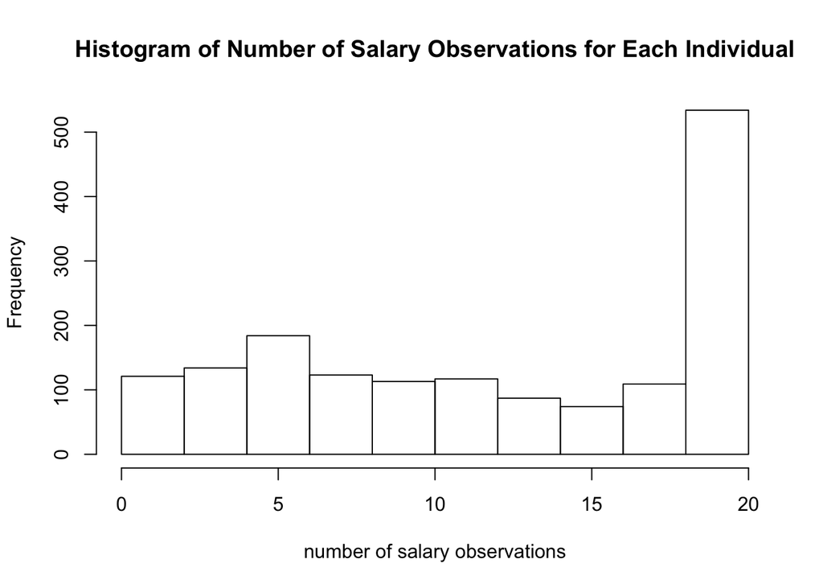

```r
hist(statsbyid$number,xlab="number of salary observations",main="Histogram of Number of Salary Observations for Each Individual")
```

# Q4. Create a histogram illustrating the distribution of the median salary for UW faculty. What is the median of the median salaries of the UW faculty?

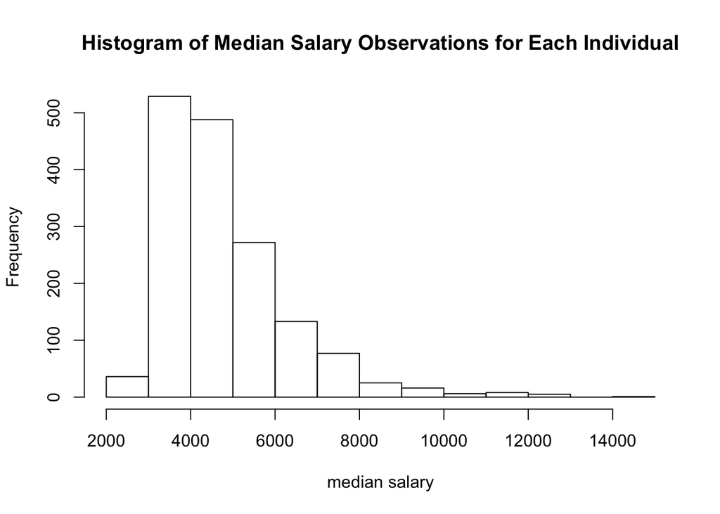

```r
hist(statsbyid$median,xlab="median salary",main="Histogram of Median Salary Observations for Each Individual")
```

```r
med_medsalary <- median(statsbyid$median)
med_medsalary
```

```
## [1] 4356.5
```

# Q5. Conduct a linear regression analysis where the median salary is the response and the difference between the maximum and minimum salary is the predictor. Provide a summary table of the estimated coefficients from the linear regression analysis. Describe the relationship between the predictor and the response from the regression analysis. Is there a significant association between median salary and the difference between the maximum and minimum salary? Provide evidence to support your conclusion.

```r
statsbyid$maxminusmin <- statsbyid$max - statsbyid$min
lm <- lm(median~maxminusmin,data=statsbyid)
summary(lm)
```

```
##
## Call:
## lm(formula = median ~ maxminusmin, data = statsbyid)
##
## Residuals:
##     Min      1Q  Median      3Q     Max
## -2530.5 -1011.4  -407.4   590.6  9886.6
##
## Coefficients:
##              Estimate Std. Error t value Pr(>|t|)
## (Intercept) 4.577e+03  6.353e+01   72.05  < 2e-16 ***
## maxminusmin 7.325e-02  1.665e-02    4.40 1.15e-05 ***
## ---
## Signif. codes:  0 '***' 0.001 '**' 0.01 '*' 0.05 '.' 0.1 ' ' 1
##
## Residual standard error: 1524 on 1594 degrees of freedom
## Multiple R-squared:  0.012,  Adjusted R-squared:  0.01138
## F-statistic: 19.36 on 1 and 1594 DF,  p-value: 1.153e-05
```

# Q6. Create a scatterplot of median salary versus the difference between the maximum and minimum salary, and add the regression line from question 5 to the plot.

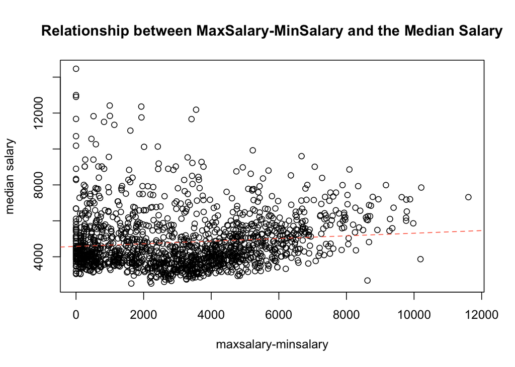

```r
plot(median~maxminusmin,data=statsbyid,xlab="maxsalary-minsalary",ylab="median salary",main="Relationship between MaxSalary-MinSalary and the Median Salary")
abline(lm,col="tomato",lty=2)
```